# Hurricane Frequency

We now turn to hurricanes.

As we did with the Florida temperature data we get the hurricane data into R using two lines of code (code chunk).

```r
L = 'http://myweb.fsu.edu/jelsner/data/US.txt'
df = read.table(L, header = TRUE)
```

Recall L locates the data sheet (US.txt) on a server. The data is read into R using the read.table function. The first argument to the read.table function is L. The result is a data frame called df.

To see what the data look like click on df in the Environment window. Data frames have rows and columns. Rows are the observations and columns are the variables.

All is the number of hurricanes hitting the United States by year. MUS is the number of major (Cat3+) hitting the U.S., G is the number of hurricanes hitting the Gulf coast, FL is the number hitting Florida, and E is the number hitting the East coast.

To see the range of years spanned by the data frame, type

```r
range(df$Year)
```

```
## [1] 1851 2010
```

To see the distribution of Florida hurricane counts, type

```r
table(df$FL)
```

```
##
##  0  1  2  3  4
## 88 42 24  5  1
```

To see if there is any change over time we make a plot as before.

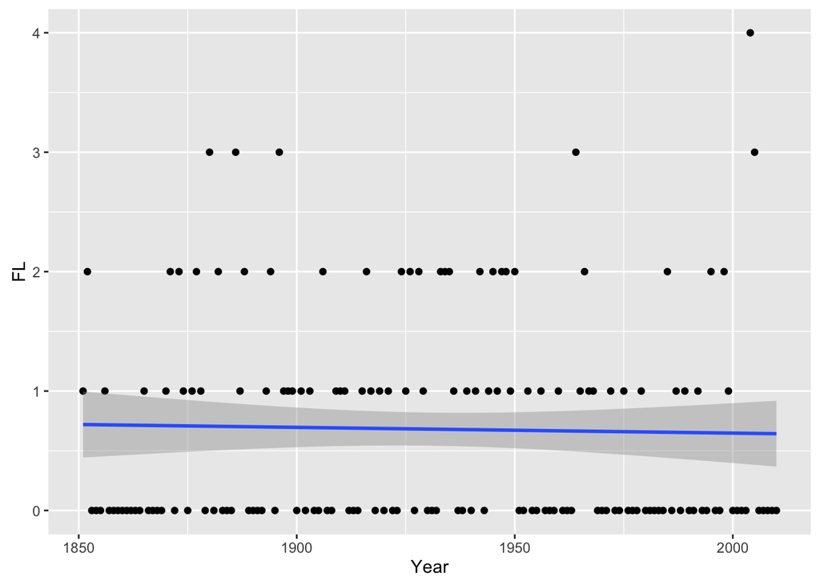

```r
library("ggplot2")
ggplot(df, aes(x = Year, y = FL)) +
  geom_point() +
  geom_smooth(method = lm)
```